# notebook

[figure not shown]

MAF1731 - Microstructure and Trading Systems

B.Eng Financial Engineering

I.F. Marco Antonio Ochoa Cardenas

Sep 2022 | Repository: [Link](https://github.com/Marcoif/Laboratorio-1-Inversion-del-capital.git)

Lab 1  
Inversión Pasiva Vs Inversión Activa

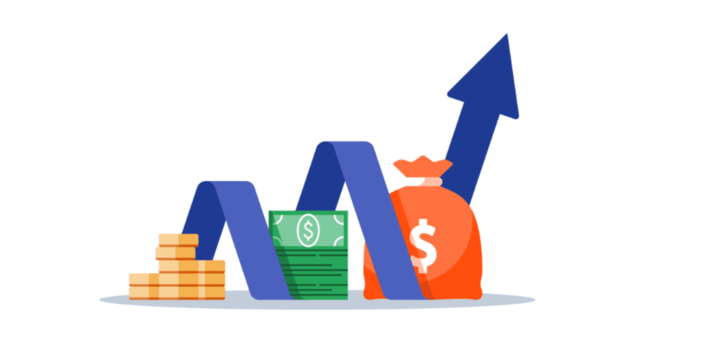

En este Laboratorio podemos ver la comparativa que tenemos entre la inversion pasiva y activa, en primera instancia la inversion pasiva como su nombre lo dice busca solo tomar una posicion dentro del mercado y conservarla atraves del tiempo, con ello podemos observar si al pasar del periodo podemos obtener un rendimiento o no. Para esto se toman en cuenta las variables como el capital inicial que tenemos y las comisiones que nos seran cobradas a la hora de comprar cierta cantidad de titulos de nuestra eleccion, otro de las variables mas importantes son los pesos que le vamos a otogar a cada una de las inversiones que tenemos, con esto y el precio que tiene cada accion en el tiempo que determinamos podemos obtener cuanta de nuestra inversion se encuentra invertida en el portafolio que formamos, cuando esta inversion pase el tiempo y tengamos mas dinero que lo que el capital y la suma de nuestras transacciones hayan tenido al principio del periodo podemos decir que hemos tenido una ganancia dentro de la inversion del portafolio.

Por otro lado la inversion activa tiene muchos de estos aspectos, se tiene la misma idea que la pasiva, con la diferencia de poner barreras o benchamrks negativos para ciertos aspectos como el que si una accion baja de cierto precio la vendemos y compramos una accion diferente, esto puede ser con o sin un limite de transacciones asi que ahora el tema importante es ver cuantas veces hacemos estas transacciones ya que siempre se nos cobrara un fee o costo de transaccion por cada vez que lo hagamos, al final en teoria esta inversion deberia ser la mas eficiente ya que no permite que nuestro portafolio este perdiendo valor en el tiempo supliendo con nuevas acciones aquellas que bajan de un cierto rango de precio.

Dejando la dudas y las preguntas principales al aire:

**- ¿La inversion Pasiva es una tecnica anticuada?**

**- ¿La inversion Activa siempre resulta mejor que la pasiva por el rebalanceo?**

**- ¿Cuales son las ventajas entre una y otra forma de invertir?**

**- Con base a los resultados ¿Cual es la mejor opcion y porque?**

*Un link de interes para conocer un poco mas acerca de este tema:*

https://fondeadora.com/producto/inversiones-pasivas-y-activas

# Introducción:

En los tiempos modernos en los que nos encontramos, las finanzas juegan un papel muy importante en la vida de los jovenes y adultos, tras el paso de los años el tema de la inversion se ha vuelto en una constante dentro de sus vidas, las estrategias de inversion, portafolios, instrumentos financieros son un tema de los cuales se comienza a tener mas recurrencia dia con dia. Estos temas llevan mucho tiempo dentro del sector peri muy poca gente conoce de verdad o tiene educacion financiera. El problema de hoy dia es que existen miles de plataformas y cursos donde las personas se pueden confundir y no tener una idea correcta de lo que estan haciendo o en donde es que estan invirtiendo su dinero, es por ello que como financieros tenemos tambien la tarea de ser asesores, donde no solo busquemos colocar activos sino que de verdad el cliente se sienta en conformidad con las decisiones que le estamos apoyando en concretar.

Como primer tema seria importante definir que es el naftrac y que es un etf para que se tenga un contexto de lo que estamos intentado y que beneficios tiene. NAFTRAC es un ETF o Tracker emitido por Nacional Financiera (Nafinsa) en abril del 2002, que busca replicar el comportamiento del Índice de Precios y Cotizaciones (IPC) de la Bolsa Mexicana de Valores.

Un ETF (fondo cotizado en bolsa) es una colección diversificada de activos (como un fondo mutuo) que cotiza en una bolsa (como una acción). Los ETF se negocian en una bolsa de valores, al igual que las acciones. Los inversionistas se sienten atraídos por los ETF debido a su bajo precio, eficiencia fiscal y facilidad de negociación.

Los mercados han estado en un constante cambio con altas y bajas y se han vivido tiempos muy complicados en los ultimos 2 años y medio, desde la pandemia donde estas empresas tuvieron sus peores margenes en la historia hasta ahora con la guerra entre estados unidos y ucrania, todos estos han sido factores para que estas inversiones y mercados se vuelvan aun mas volatiles. Es por ello que el largo plazo se ha visto afectado en tasas debido a que no se tiene certidumbre del futuro del mercado financiero global.

[figure not shown]

objetivo:

El objetivo de este laboratorio es realizar una comparación entre la inversión activa y pasiva, con un capital fijo de un millon de pesos, donde en la primera parte se realizará solo la compra con las comisiones del ultimo dia de la primera fecha dada y esperaremos el tiempo que se brindó para ver cuanto interes generamos al final del periodo, por otro lado en la inversión activa tendremos rebalanceos cuando una de nuestras acciones baje un porcentaje importante de precio

# 2. Install/Load Packages and Depedencies

```python
import data as dt
import functions as fn
import datetime as datetime
```

## 2.2 Python Packages

# 3. Data Description

Dentro de la bolsa Mexicana de Valores exite un grupo de las empresas más grandes de Mexico en ellas se encuentran empresas como America movil, Banregio y Peñoles, donde podriamos formar nuestro propio portafolio con auqellas que nos gusten mas o creamos que son mejores para nuestra inversion, sin embargo existe un ETF conocido como Naftrac el cual tiene a todas las empresas y se encarga de replicar este indice, aqui despues de descargarlos de yahoo finance los podemos observar

```python
# Base de datos de las acciones del naftrac estos son los datos que se nos brindaron por medio de archivos csv
import data as dt
dt.data.head(10)
```

|  | Ticker | Nombre | Clase de activo | Peso (%) | Precio | Acciones | Valor de mercado | Valor nominal | Sector | ISIN | Bolsa de valores | Ubicación | Moneda | Mercado de divisas | Tipo de Cambio |
| --- | --- | --- | --- | --- | --- | --- | --- | --- | --- | --- | --- | --- | --- | --- | --- |
| 0 | AMXL | AMERICA MOVIL L | Equity | 0.1443 | 19.86 | 413,409,434.00 | 8,210,311,359.24 | 8,210,311,359.24 | Comunicación | MXP001691213 | Bolsa Mexicana De Valores | México | MXN | MXN | 1.00 |
| 1 | WALMEX | WALMART DE MEXICO V | Equity | 0.1175 | 72.16 | 92,676,094.00 | 6,687,506,943.04 | 6,687,506,943.04 | Productos básicos de consumo | MX01WA000038 | Bolsa Mexicana De Valores | México | MXN | MXN | 1.00 |
| 2 | GFNORTEO | GPO FINANCE BANORTE | Equity | 0.1062 | 134.71 | 44,856,411.00 | 6,042,607,125.81 | 6,042,607,125.81 | Financieros | MXP370711014 | Bolsa Mexicana De Valores | México | MXN | MXN | 1.00 |
| 3 | GMEXICOB | GRUPO MEXICO B | Equity | 0.0957 | 95.52 | 56,991,495.00 | 5,443,827,602.40 | 5,443,827,602.40 | Materiales | MXP370841019 | Bolsa Mexicana De Valores | México | MXN | MXN | 1.00 |
| 4 | FEMSAUBD | FOMENTO ECONOMICO MEXICANO | Equity | 0.0906 | 153.44 | 33,620,399.00 | 5,158,714,022.56 | 5,158,714,022.56 | Productos básicos de consumo | MXP320321310 | Bolsa Mexicana De Valores | México | MXN | MXN | 1.00 |
| 5 | CEMEXCPO | CEMEX CPO | Equity | 0.0437 | 8.98 | 277,040,698.00 | 2,487,825,468.04 | 2,487,825,468.04 | Materiales | MXP225611567 | Bolsa Mexicana De Valores | México | MXN | MXN | 1.00 |
| 6 | GAPB | GRUPO AEROPORTUARIO DEL PACIFICO | Equity | 0.0350 | 314.03 | 6,347,295.00 | 1,993,241,048.85 | 1,993,241,048.85 | Industriales | MX01GA000004 | Bolsa Mexicana De Valores | México | MXN | MXN | 1.00 |
| 7 | TLEVISACPO | GRUPO TELEVISA | Equity | 0.0308 | 37.88 | 46,305,410.00 | 1,754,048,930.80 | 1,754,048,930.80 | Comunicación | MXP4987V1378 | Bolsa Mexicana De Valores | México | MXN | MXN | 1.00 |
| 8 | BIMBOA | GRUPO BIMBO A | Equity | 0.0299 | 62.90 | 27,027,409.00 | 1,700,024,026.10 | 1,700,024,026.10 | Productos básicos de consumo | MXP495211262 | Bolsa Mexicana De Valores | México | MXN | MXN | 1.00 |
| 9 | ASURB | GRUPO AEROPORTUARIO DEL SURESTE B | Equity | 0.0282 | 445.37 | 3,600,210.00 | 1,603,425,527.70 | 1,603,425,527.70 | Industriales | MXP001661018 | Bolsa Mexicana De Valores | México | MXN | MXN | 1.00 |

# 4. A particular Process

Aqui podemos ver las fechas que se van a tomar para ver la posicion de la inversion

```python
fechas= fn.f_fechas(p_archivos=dt.archivos)
print(fechas["t_fechas"])
```

```
['2020-01-31', '2020-02-28', '2020-03-31', '2020-04-30', '2020-05-29', '2020-06-30', '2020-07-31', '2020-08-31', '2020-09-30', '2020-10-30', '2020-11-30', '2020-12-31', '2021-01-29', '2021-02-26', '2021-03-31', '2021-04-30', '2021-05-31', '2021-06-30', '2021-07-30', '2021-08-31', '2021-09-30', '2021…
```

Una vez viendo la informacion que tenemos disponible tanto para la inversion activa como pasiva podemos ver como son los periodos que tenemos apra realizar las comparaciones y desde cuanto debemos tomar las fechas para revisar cual es mejor que otra, como se puede observar hay acciones como liverpol que cambio de nombre dentro de la bolsa y tendremos que ajustar ese ticker para que nos lo pueda buscar

# Aqui muestro todos los tickers que tengo dentro de los archivos y con los que se hara todo el analisis

```python
global_tickers = fn.f_global_tickers(dt.data_archivos, dt.filenames)
global_tickers
```

```
['AC.MX',
 'ALFAA.MX',
 'ALPEKA.MX',
 'ALSEA.MX',
 'AMXL.MX',
 'ASURB.MX',
 'BBAJIOO.MX',
 'BIMBOA.MX',
 'BOLSAA.MX',
 'BSMXB.MX',
 'CEMEXCPO.MX',
 'CUERVO.MX',
 'ELEKTRA.MX',
 'FEMSAUBD.MX',
 'GAPB.MX',
 'GCARSOA1.MX',
 'GCC.MX',
 'GENTERA.MX',
 'GFINBURO.MX',
 'GFNORTEO.MX',
 'GMEXICOB.MX',
 'GRUMAB.MX',
 'IENOVA.MX',
 'KIMBERA.MX',
 'KOFUBL.MX',
 'LABB.MX',
 'LIVEPOLC.1.MX',
 'MEGACPO.MX',
 'MXN.MX',
 'NMKA.MX',
 'OMAB.MX',
 'ORBIA.MX',
 'PE&OLES.MX',
 'PINFRA.MX',
 'Q.MX',
 'RA.MX',
 'SITES1A-1.MX',
 'SITESB.1.MX',
 'TLEVISACPO.MX',
 'USD.MX',
 'VESTA.MX',
 'VOLARA.MX',
 'WALMEX.MX']
```

## Bajar los datos de Yahoo finance para ver las cotizaciones que tienen desde la fecha que se requiere hasta el final del periodo solicitado

```python
prices= fn.prices_download(global_tickers)
prices.head()
```

```
['AC.MX', 'ALFAA.MX', 'ALPEKA.MX', 'ALSEA.MX', 'AMXL.MX', 'ASURB.MX', 'BBAJIOO.MX', 'BIMBOA.MX', 'BOLSAA.MX', 'BSMXB.MX', 'CEMEXCPO.MX', 'CUERVO.MX', 'ELEKTRA.MX', 'FEMSAUBD.MX', 'GAPB.MX', 'GCARSOA1.MX', 'GCC.MX', 'GENTERA.MX', 'GFINBURO.MX', 'GFNORTEO.MX', 'GMEXICOB.MX', 'GRUMAB.MX', 'IENOVA.MX', …
[*********************100%***********************]  37 of 37 completed
se tardo 2.6138389110565186 segundos
```

| Date | VESTA.MX Open | VESTA.MX High | VESTA.MX Low | VESTA.MX Close | VESTA.MX Adj Close | VESTA.MX Volume | WALMEX.MX Open | WALMEX.MX High | WALMEX.MX Low | WALMEX.MX Close | ... | BOLSAA.MX Low | BOLSAA.MX Close | BOLSAA.MX Adj Close | BOLSAA.MX Volume | CEMEXCPO.MX Open | CEMEXCPO.MX High | CEMEXCPO.MX Low | CEMEXCPO.MX Close | CEMEXCPO.MX Adj Close | CEMEXCPO.MX Volume |
| --- | --- | --- | --- | --- | --- | --- | --- | --- | --- | --- | --- | --- | --- | --- | --- | --- | --- | --- | --- | --- | --- |
| 2020-01-31 | 34.700001 | 35.439999 | 33.080002 | 34.529999 | 33.961514 | 924578 | 56.060001 | 56.439999 | 54.470001 | 55.220001 | ... | 41.849998 | 43.439999 | 37.607738 | 512499 | 7.82 | 7.85 | 7.57 | 7.595 | 7.595 | 54373655 |
| 2020-02-04 | 33.700001 | 36.299999 | 33.700001 | 35.334999 | 34.753262 | 1139416 | 55.049999 | 57.169998 | 55.000000 | 56.625000 | ... | 43.000000 | 43.349998 | 37.529823 | 1033550 | 7.73 | 7.99 | 7.73 | 7.945 | 7.945 | 51832333 |
| 2020-02-05 | 35.740002 | 35.740002 | 34.470001 | 34.849998 | 34.276245 | 1471381 | 56.919998 | 57.200001 | 55.599998 | 56.119999 | ... | 41.910000 | 42.840000 | 37.088291 | 761030 | 7.98 | 8.00 | 7.73 | 7.750 | 7.750 | 30024917 |
| 2020-02-06 | 34.669998 | 34.669998 | 34.009998 | 34.340000 | 33.774643 | 2185483 | 56.369999 | 56.540001 | 55.119999 | 55.209999 | ... | 42.110001 | 43.270000 | 37.460564 | 1134663 | 7.75 | 7.84 | 7.67 | 7.750 | 7.750 | 20392529 |
| 2020-02-07 | 33.980000 | 34.410000 | 33.799999 | 34.150002 | 33.587769 | 1515386 | 55.119999 | 56.180000 | 54.810001 | 56.000000 | ... | 42.220001 | 43.009998 | 37.235466 | 837008 | 7.72 | 7.85 | 7.68 | 7.790 | 7.790 | 18541799 |

5 rows × 222 columns

### Al estar revisando los datos de descargas y los datos que se tenian dentro de los csv me pude percatar que no estan cuadrados correctamente, ya que los archivos no concuerdan con los precios de cierrre de las acciones una vez descargadas de yahoofinance, es por ello que se creo esta funcion interna para que pueda cuadrar cronologicamente estos datos

```python
dates_list = [datetime.datetime.strptime(i, "%Y%m%d").date() for i in fechas['index_fechas']]
for i in range(len(fechas['index_fechas'])):
    for j in range(31):
        if fechas['index_fechas'][i] in dt.filenames[j]:
            dt.data_archivos[fechas['index_fechas'][i]]=dt.data_archivos.pop(dt.filenames[j])
            dt.data_archivos[dates_list[i]]=dt.data_archivos.pop(fechas['index_fechas'][i])
```

```python
dt.data_archivos[dates_list[0]]
```

|  | Ticker | Nombre | Clase de activo | Peso (%) | Precio | Acciones | Valor de mercado | Valor nominal | Sector | ISIN | Bolsa de valores | Ubicación | Moneda | Mercado de divisas | Tipo de Cambio |
| --- | --- | --- | --- | --- | --- | --- | --- | --- | --- | --- | --- | --- | --- | --- | --- |
| 0 | AMXL | AMERICA MOVIL L | Equity | 0.1370 | 15.69 | 634,706,362.00 | 9,958,542,819.78 | 9,958,542,819.78 | Comunicación | MXP001691213 | Bolsa Mexicana De Valores | México | MXN | MXN | 1.00 |
| 1 | FEMSAUBD | FOMENTO ECONOMICO MEXICANO | Equity | 0.1185 | 170.37 | 50,554,056.00 | 8,612,894,520.72 | 8,612,894,520.72 | Productos básicos de consumo | MXP320321310 | Bolsa Mexicana De Valores | México | MXN | MXN | 1.00 |
| 2 | GFNORTEO | GPO FINANCE BANORTE | Equity | 0.1064 | 116.09 | 66,664,611.00 | 7,739,094,690.99 | 7,739,094,690.99 | Financieros | MXP370711014 | Bolsa Mexicana De Valores | México | MXN | MXN | 1.00 |
| 3 | WALMEX | WALMART DE MEXICO V | Equity | 0.1039 | 54.85 | 137,735,088.00 | 7,554,769,576.80 | 7,554,769,576.80 | Productos básicos de consumo | MX01WA000038 | Bolsa Mexicana De Valores | México | MXN | MXN | 1.00 |
| 4 | GMEXICOB | GRUPO MEXICO B | Equity | 0.0603 | 50.46 | 86,818,080.00 | 4,380,840,316.80 | 4,380,840,316.80 | Materiales | MXP370841019 | Bolsa Mexicana De Valores | México | MXN | MXN | 1.00 |
| 5 | CEMEXCPO | CEMEX CPO | Equity | 0.0430 | 7.60 | 411,737,485.00 | 3,129,204,886.00 | 3,129,204,886.00 | Materiales | MXP225611567 | Bolsa Mexicana De Valores | México | MXN | MXN | 1.00 |
| 6 | TLEVISACPO | GRUPO TELEVISA | Equity | 0.0396 | 41.83 | 68,818,731.00 | 2,878,687,517.73 | 2,878,687,517.73 | Comunicación | MXP4987V1378 | Bolsa Mexicana De Valores | México | MXN | MXN | 1.00 |
| 7 | GAPB | GRUPO AEROPORTUARIO DEL PACIFICO | Equity | 0.0329 | 233.54 | 10,246,476.00 | 2,392,962,005.04 | 2,392,962,005.04 | Industriales | MX01GA000004 | Bolsa Mexicana De Valores | México | MXN | MXN | 1.00 |
| 8 | ELEKTRA | GRUPO ELEKTRA | Equity | 0.0302 | 1383.14 | 1,586,746.00 | 2,194,691,862.44 | 2,194,691,862.44 | Financieros | MX01EL000003 | Bolsa Mexicana De Valores | México | MXN | MXN | 1.00 |
| 9 | ASURB | GRUPO AEROPORTUARIO DEL SURESTE B | Equity | 0.0275 | 363.07 | 5,500,537.00 | 1,997,079,968.59 | 1,997,079,968.59 | Industriales | MXP001661018 | Bolsa Mexicana De Valores | México | MXN | MXN | 1.00 |
| 10 | KOFUBL | COCA-COLA FEMSA CLASS UBL UNITS | Equity | 0.0226 | 114.94 | 14,284,502.00 | 1,641,860,659.88 | 1,641,860,659.88 | Productos básicos de consumo | MX01KO000002 | Bolsa Mexicana De Valores | México | MXN | MXN | 1.00 |
| 11 | KIMBERA | KIMBERLY-CLARK DE MEXICO CLASS A | Equity | 0.0206 | 38.97 | 38,402,911.00 | 1,496,561,441.67 | 1,496,561,441.67 | Productos básicos de consumo | MXP606941179 | Bolsa Mexicana De Valores | México | MXN | MXN | 1.00 |
| 12 | BIMBOA | GRUPO BIMBO A | Equity | 0.0187 | 33.81 | 40,264,846.00 | 1,361,354,443.26 | 1,361,354,443.26 | Productos básicos de consumo | MXP495211262 | Bolsa Mexicana De Valores | México | MXN | MXN | 1.00 |
| 13 | OMAB | GRUPO AEROPORTUARIO DEL CENTRO NOR | Equity | 0.0185 | 143.87 | 9,356,755.00 | 1,346,156,341.85 | 1,346,156,341.85 | Industriales | MX01OM000018 | Bolsa Mexicana De Valores | México | MXN | MXN | 1.00 |
| 14 | AC | ARCA CONTINENTAL | Equity | 0.0177 | 107.01 | 11,996,909.00 | 1,283,789,232.09 | 1,283,789,232.09 | Productos básicos de consumo | MX01AC100006 | Bolsa Mexicana De Valores | México | MXN | MXN | 1.00 |
| 15 | GFINBURO | GRUPO FINANCIERO INBURSA SRIES O | Equity | 0.0176 | 21.49 | 59,441,550.00 | 1,277,398,909.50 | 1,277,398,909.50 | Financieros | MXP370641013 | Bolsa Mexicana De Valores | México | MXN | MXN | 1.00 |
| 16 | IENOVA | INFRAESTRUCTURA ENERGETICA NOVA | Equity | 0.0173 | 88.76 | 14,143,883.00 | 1,255,411,055.08 | 1,255,411,055.08 | Servicios | MX01IE060002 | Bolsa Mexicana De Valores | México | MXN | MXN | 1.00 |
| 17 | PINFRA | PROMOTORA Y OPERADORA DE INFRAESTR | Equity | 0.0168 | 203.86 | 5,996,206.00 | 1,222,386,555.16 | 1,222,386,555.16 | Industriales | MX01PI000005 | Bolsa Mexicana De Valores | México | MXN | MXN | 1.00 |
| 18 | GRUMAB | GRUMA | Equity | 0.0168 | 200.80 | 6,086,372.00 | 1,222,143,497.60 | 1,222,143,497.60 | Productos básicos de consumo | MXP4948K1056 | Bolsa Mexicana De Valores | México | MXN | MXN | 1.00 |
| 19 | ORBIA | ORBIA ADVANCE CORP SA DE CV | Equity | 0.0167 | 44.21 | 27,416,516.00 | 1,212,084,172.36 | 1,212,084,172.36 | Materiales | MX01OR010004 | Bolsa Mexicana De Valores | México | MXN | MXN | 1.00 |
| 20 | ALFAA | ALFA A | Equity | 0.0151 | 14.14 | 77,753,590.00 | 1,099,435,762.60 | 1,099,435,762.60 | Industriales | MXP000511016 | Bolsa Mexicana De Valores | México | MXN | MXN | 1.00 |
| 21 | GCARSOA1 | GRUPO CARSO SERIES A1 | Equity | 0.0116 | 68.13 | 12,402,870.00 | 845,007,533.10 | 845,007,533.10 | Industriales | MXP461181085 | Bolsa Mexicana De Valores | México | MXN | MXN | 1.00 |
| 22 | PE&OLES | INDUST PENOLES | Equity | 0.0091 | 197.37 | 3,351,332.00 | 661,452,396.84 | 661,452,396.84 | Materiales | MXP554091415 | Bolsa Mexicana De Valores | México | MXN | MXN | 1.00 |
| 23 | ALSEA | ALSEA DE CV | Equity | 0.0086 | 45.76 | 13,685,387.00 | 626,243,309.12 | 626,243,309.12 | Consumo discrecional | MXP001391012 | Bolsa Mexicana De Valores | México | MXN | MXN | 1.00 |
| 24 | BBAJIOO | BANCO DEL BAJIO INSTITUCION DE BAN | Equity | 0.0083 | 31.16 | 19,419,618.00 | 605,115,296.88 | 605,115,296.88 | Financieros | MX41BB000000 | Bolsa Mexicana De Valores | México | MXN | MXN | 1.00 |
| 25 | GENTERA | GENTERA SAB DE CV | Equity | 0.0081 | 21.28 | 27,837,884.00 | 592,390,171.52 | 592,390,171.52 | Financieros | MX01GE0E0004 | Bolsa Mexicana De Valores | México | MXN | MXN | 1.00 |
| 26 | MEGACPO | MEGACABLE HOLDINGS CPO | Equity | 0.0079 | 70.31 | 8,132,057.00 | 571,764,927.67 | 571,764,927.67 | Comunicación | MX01ME090003 | Bolsa Mexicana De Valores | México | MXN | MXN | 1.00 |
| 27 | LIVEPOLC.1 | EL PUERTO DE LIVERPOOL C1 | Equity | 0.0074 | 99.84 | 5,369,850.00 | 536,125,824.00 | 536,125,824.00 | Consumo discrecional | MXP369181377 | Bolsa Mexicana De Valores | México | MXN | MXN | 1.00 |
| 28 | BOLSAA | BOLSA MEXICANA DE VALORES | Equity | 0.0072 | 43.52 | 12,096,692.00 | 526,448,035.84 | 526,448,035.84 | Financieros | MX01BM1B0000 | Bolsa Mexicana De Valores | México | MXN | MXN | 1.00 |
| 29 | CUERVO | BECLE SA DE CV | Equity | 0.0067 | 35.04 | 13,914,078.00 | 487,549,293.12 | 487,549,293.12 | Productos básicos de consumo | MX01CU010003 | Bolsa Mexicana De Valores | México | MXN | MXN | 1.00 |
| 30 | LABB | GENOMMA LAB INTERNATIONAL | Equity | 0.0062 | 22.38 | 20,238,033.00 | 452,927,178.54 | 452,927,178.54 | Cuidado de la Salud | MX01LA010006 | Bolsa Mexicana De Valores | México | MXN | MXN | 1.00 |
| 31 | GCC | GRUPO CEMENTOS | Equity | 0.0059 | 97.92 | 4,405,616.00 | 431,397,918.72 | 431,397,918.72 | Materiales | MX01GC2M0006 | Bolsa Mexicana De Valores | México | MXN | MXN | 1.00 |
| 32 | BSMXB | BANCO SANTANDER B SA | Equity | 0.0057 | 27.09 | 15,363,779.00 | 416,204,773.11 | 416,204,773.11 | Financieros | MX41BS060005 | Bolsa Mexicana De Valores | México | MXN | MXN | 1.00 |
| 33 | RA | REGIONAL SAB DE CV | Equity | 0.0044 | 108.21 | 2,942,966.00 | 318,458,350.86 | 318,458,350.86 | Financieros | MX01R0000006 | Bolsa Mexicana De Valores | México | MXN | MXN | 1.00 |
| 34 | MXN | MXN CASH | Cash | 0.0027 | 100.00 | 198,458,917.00 | 198,458,917.44 | 198,458,917.44 | Liquidez | - | - | México | MXN | MXN | 1.00 |
| 35 | ALPEKA | ALPEK SA DE CV | Equity | 0.0025 | 17.72 | 10,361,591.00 | 183,607,392.52 | 183,607,392.52 | Materiales | MX01AL0C0004 | Bolsa Mexicana De Valores | México | MXN | MXN | 1.00 |

Al tener los datos de yahoofinance de forma diaria solo nos interesan los precios de cierre en las fechas especificas de cada archivo, es por ello que se creo la funcion clean_prices la cual solo nos muestra esos precios en las fechas solicitadas de todos los tickers

```python
clean_prices, data_close = fn.clean_price(data_archivos=dt.data_archivos, dates_list=dates_list, data=prices, t_fechas=fechas['t_fechas'])
clean_prices.head()
```

| Date | AC.MX | ALFAA.MX | ALPEKA.MX | ALSEA.MX | AMXL.MX | ASURB.MX | BBAJIOO.MX | BIMBOA.MX | BOLSAA.MX | CEMEXCPO.MX | ... | LABB.MX | LIVEPOLC-1.MX | MEGACPO.MX | OMAB.MX | ORBIA.MX | PE&OLES.MX | PINFRA.MX | RA.MX | TLEVISACPO.MX | WALMEX.MX |
| --- | --- | --- | --- | --- | --- | --- | --- | --- | --- | --- | --- | --- | --- | --- | --- | --- | --- | --- | --- | --- | --- |
| 2020-01-31 | 107.120003 | 14.19 | 17.73 | 45.825001 | 15.695 | 363.149994 | 31.205000 | 33.805000 | 43.439999 | 7.595 | ... | 22.350000 | 99.714996 | 70.680000 | 143.755005 | 44.410000 | 197.339996 | 204.115005 | 107.995003 | 41.965000 | 55.220001 |
| 2020-02-28 | 107.989998 | 12.57 | 13.32 | 39.919998 | 15.520 | 324.890015 | 30.700001 | 29.690001 | 41.580002 | 6.340 | ... | 19.920000 | 91.809998 | 65.900002 | 129.270004 | 38.490002 | 177.440002 | 192.130005 | 109.430000 | 36.830002 | 55.200001 |
| 2020-03-31 | 95.610001 | 6.40 | 8.45 | 15.180000 | 14.050 | 223.360001 | 20.480000 | 34.480000 | 36.240002 | 4.930 | ... | 18.870001 | 51.770000 | 64.879997 | 80.169998 | 26.090000 | 157.880005 | 159.190002 | 62.490002 | 27.299999 | 55.750000 |
| 2020-04-30 | 92.830002 | 9.86 | 11.46 | 19.870001 | 14.600 | 241.389999 | 19.000000 | 35.590000 | 43.779999 | 5.070 | ... | 19.410000 | 60.709999 | 60.070000 | 87.800003 | 28.440001 | 186.080002 | 167.429993 | 59.070000 | 25.610001 | 57.970001 |
| 2020-05-29 | 98.910004 | 11.74 | 15.51 | 18.750000 | 14.810 | 228.550003 | 20.219999 | 34.669998 | 42.490002 | 5.250 | ... | 20.209999 | 55.480000 | 67.070000 | 97.599998 | 32.540001 | 210.869995 | 167.210007 | 61.580002 | 26.270000 | 55.349998 |

5 rows × 33 columns

Este es el primer paso de lo que se solicito como proceso de inversion pasiva, es el cuadro donde tenemos todos los tickers, con el nombre de la accion, peso y el precio para las cotizaciones

```python
pos_datos = fn.pasiva_ini(data_archivos=dt.data_archivos, dates_list=dates_list, precios=clean_prices)
pos_datos.head(10)
```

|  | Ticker | Nombre | Peso (%) | Precio |
| --- | --- | --- | --- | --- |
| 0 | AC.MX | ARCA CONTINENTAL | 0.0177 | 107.120003 |
| 1 | ALFAA.MX | ALFA A | 0.0151 | 14.190000 |
| 2 | ALPEKA.MX | ALPEK SA DE CV | 0.0025 | 17.730000 |
| 3 | ALSEA.MX | ALSEA DE CV | 0.0086 | 45.825001 |
| 4 | AMXL.MX | AMERICA MOVIL L | 0.1370 | 15.695000 |
| 5 | ASURB.MX | GRUPO AEROPORTUARIO DEL SURESTE B | 0.0275 | 363.149994 |
| 6 | BBAJIOO.MX | BANCO DEL BAJIO INSTITUCION DE BAN | 0.0083 | 31.205000 |
| 7 | BIMBOA.MX | GRUPO BIMBO A | 0.0187 | 33.805000 |
| 8 | BOLSAA.MX | BOLSA MEXICANA DE VALORES | 0.0072 | 43.439999 |
| 9 | CEMEXCPO.MX | CEMEX CPO | 0.0430 | 7.595000 |

Finalmente obtenemos la tabla final donde podemos ver el rendimiento que se lleva en el año y cuanto rendimiento acumulado hubieramos tenido si hubieramos seguido esa inversion desde la primera fecha hasta el final de los 2 años y medio, es decir si hubieramos tenido esta inversion a traves de ese periodo, nuestro rendimiento acumulado hubierado sido del 13.66%

```python
results=fn.inv_pasiva(pos_datos, dates_list, clean_prices)
results.tail()
```

|  | timestamp | Capital | rend | rend_acum |
| --- | --- | --- | --- | --- |
| 26 | 2022-02-28 | 1.219170e+06 | 0.045548 | 0.236978 |
| 27 | 2022-03-31 | 1.291957e+06 | 0.059702 | 0.296680 |
| 28 | 2022-04-29 | 1.175993e+06 | -0.089758 | 0.206922 |
| 29 | 2022-05-31 | 1.182316e+06 | 0.005376 | 0.212298 |
| 30 | 2022-06-30 | 1.092909e+06 | -0.075620 | 0.136678 |

# Inversion Activa

Para la inversion activa vamos a utilizar las ponderaciones que vienen en el NAFTRAC en la primera fecha mostrada, cuando un activo baje del 5% vamos a comprar 2.5% menos del activo y viceversa en caso de que este suba de precio, cuando vendamos tendremos el cash para seguir rebalanceando y si se nos acaba el cash ahi dejamos de rebaleancer hasta que tengamos de nuevo cash en la cartera

```python
pos_activa, cash_activa, cash_ini = fn.activa_ini(dt.data_archivos, dates_list, clean_prices)
pos_activa.head(10)
```

|  | Ticker | Nombre | Peso (%) | Precio | Capital | Títulos | Postura | Comisión |
| --- | --- | --- | --- | --- | --- | --- | --- | --- |
| 0 | AMXL.MX | AMERICA MOVIL L | 0.1370 | 15.695000 | 136828.750 | 8717 | 136813.312340 | 171.016640 |
| 1 | FEMSAUBD.MX | FOMENTO ECONOMICO MEXICANO | 0.1185 | 170.255005 | 118351.875 | 695 | 118327.228394 | 147.909035 |
| 2 | GFNORTEO.MX | GPO FINANCE BANORTE | 0.1064 | 116.129997 | 106267.000 | 915 | 106258.947487 | 132.823684 |
| 3 | WALMEX.MX | WALMART DE MEXICO V | 0.1039 | 55.220001 | 103770.125 | 1879 | 103758.382294 | 129.697978 |
| 4 | GMEXICOB.MX | GRUPO MEXICO B | 0.0603 | 50.215000 | 60224.625 | 1199 | 60207.785183 | 75.259731 |
| 5 | CEMEXCPO.MX | CEMEX CPO | 0.0430 | 7.595000 | 42946.250 | 5654 | 42942.128814 | 53.677661 |
| 6 | TLEVISACPO.MX | GRUPO TELEVISA | 0.0396 | 41.965000 | 39550.500 | 942 | 39531.030144 | 49.413788 |
| 7 | GAPB.MX | GRUPO AEROPORTUARIO DEL PACIFICO | 0.0329 | 233.854996 | 32858.875 | 140 | 32739.699402 | 40.924624 |
| 8 | ELEKTRA.MX | GRUPO ELEKTRA | 0.0302 | 1382.750000 | 30162.250 | 21 | 29037.750000 | 36.297187 |
| 9 | ASURB.MX | GRUPO AEROPORTUARIO DEL SURESTE B | 0.0275 | 363.149994 | 27465.625 | 75 | 27236.249542 | 34.045312 |

# Conclusion

# 6. References

Castillo, G. A. (2021, 8 noviembre). Inversión activa versus pasiva: ¿Qué estrategia es mejor? Recuperado 7 de septiembre de 2022, de https://www.forbesargentina.com/money/inversion-activa-versus-pasiva-que-estrategia-mejor-n9686

Inversiones pasivas y activas. (s. f.). Fondeadora. Recuperado 7 de septiembre de 2022, de https://fondeadora.com/producto/inversiones-pasivas-y-activas